# Intermediate R

A possible implementation of the `interpret()` function is already available in the editor. In this exercise you’ll be writing another function that will use the `interpret()` function to interpret *all* the data from your daily profile views inside a vector. Furthermore, your function will return the sum of views on popular days, if asked for. A `for` loop is ideal for iterating over all the vector elements. The ability to return the sum of views on popular days is something you can code through a function argument with a default value.

```r
# The linkedin and facebook vectors have already been created for you
linkedin <- c(16, 9, 13, 5, 2, 17, 14)
facebook <- c(17, 7, 5, 16, 8, 13, 14)

# The interpret() can be used inside interpret_all()
interpret <- function(num_views) {
  if (num_views > 15) {
    print("You're popular!")
    return(num_views)
  } else {
    print("Try to be more visible!")
    return(0)
  }
}

# Define the interpret_all() function
# views: vector with data to interpret
# return_sum: return total number of views on popular days?
interpret_all <- function(views, return_sum = TRUE) {
  count <- 0

  for (v in views) {
    count <- count + interpret(v)
  }

  if (return_sum) {
    return(count)
  } else {
    return(NULL)
  }
}

# Call the interpret_all() function on both linkedin and facebook
interpret_all(linkedin)
```

```
## [1] "You're popular!"
## [1] "Try to be more visible!"
## [1] "Try to be more visible!"
## [1] "Try to be more visible!"
## [1] "Try to be more visible!"
## [1] "You're popular!"
## [1] "Try to be more visible!"
```

```
## [1] 33
```

```r
interpret_all(facebook)
```

```
## [1] "You're popular!"
## [1] "Try to be more visible!"
## [1] "Try to be more visible!"
## [1] "You're popular!"
## [1] "Try to be more visible!"
## [1] "Try to be more visible!"
## [1] "Try to be more visible!"
```

```
## [1] 33
```

Perfect! Have a look at the results; it appears that the sum of views on popular days are the same for Facebook and LinkedIn, what a coincidence! Your different social profiles must be fairly balanced ;-) Head over to the next video!

**R Packages**

- where do `mean()`, `list()`, and `sample()` come from?
- part of R packages
- code, data, documentation, and tests
- easy to share
- examples: `base`, `ggvis`

**Install packages**

- `base` package: automatically installed
- `ggvis` package: not installed yet

```
install.packages("ggvis")
```

- CRAN: Comprehensive R Archive Network

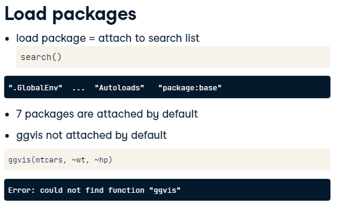

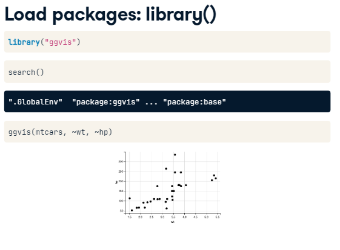

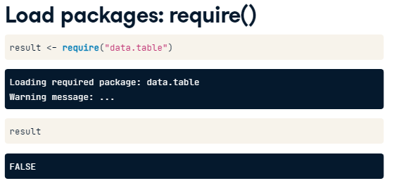

**Load an R Package**

There are basically two extremely important functions when it comes down to R packages:

- [install.packages()](http://www.rdocumentation.org/packages/utils/functions/install.packages), which as you can expect, installs a given package.
- [library()](http://www.rdocumentation.org/packages/base/functions/library) which loads packages, i.e. attaches them to the search list on your R workspace.

To install packages, you need administrator privileges. This means that [install.packages()](http://www.rdocumentation.org/packages/utils/functions/install.packages) will thus not work in the DataCamp interface. However, almost all CRAN packages are installed on our servers. You can load them with [library()](http://www.rdocumentation.org/packages/base/functions/library).

In this exercise, you’ll be learning how to load the `ggplot2` package, a powerful package for data visualization. You’ll use it to create a plot of two variables of the `mtcars` data frame. The data has already been prepared for you in the workspace.

Before starting, execute the following commands in the console:

- `search()`, to look at the currently attached packages and
- `qplot(mtcars$wt, mtcars$hp)`, to build a plot of two variables of the `mtcars` data frame. An error should occur, because you haven’t loaded the `ggplot2` package yet!

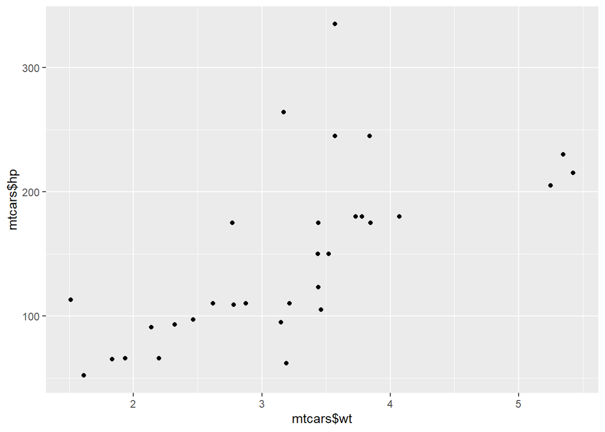

```r
# Load the ggplot2 package
library("ggplot2")

# Retry the qplot() function
qplot(mtcars$wt, mtcars$hp)
```

```r
# Check out the currently attached packages again
search()
```

```
##  [1] ".GlobalEnv"        "package:ggplot2"   "package:stats"
##  [4] "package:graphics"  "package:grDevices" "package:utils"
##  [7] "package:datasets"  "package:methods"   "Autoloads"
## [10] "package:base"
```

Awesome! Notice how `search()` and `library()` are closely interconnected functions. Head over to the next exercise.

**lapply**

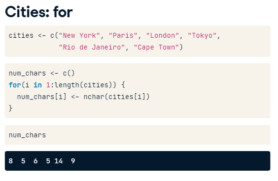

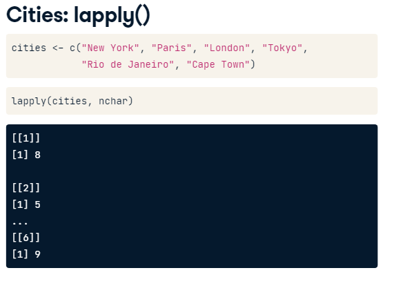

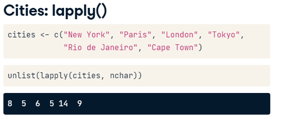

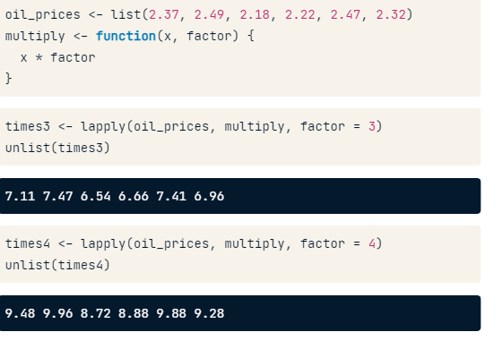

**Use lapply with a built-in R function**

Before you go about solving the exercises below, have a look at the documentation of the [lapply()](http://www.rdocumentation.org/packages/base/functions/lapply) function. The Usage section shows the following expression:

```
lapply(X, FUN, ...)
```

To put it generally, `lapply` takes a vector or list `X`, and applies the function `FUN` to each of its members. If `FUN` requires additional arguments, you pass them after you’ve specified `X` and `FUN` (`...`). The output of `lapply()` is a list, the same length as `X`, where each element is the result of applying `FUN` on the corresponding element of `X`.

Now that you are truly brushing up on your data science skills, let’s revisit some of the most relevant figures in data science history. We’ve compiled a vector of famous mathematicians/statisticians and the year they were born. Up to you to extract some information!

```r
# The vector pioneers has already been created for you
pioneers <- c("GAUSS:1777", "BAYES:1702", "PASCAL:1623", "PEARSON:1857")

# Split names from birth year
split_math <- strsplit(pioneers, split = ":")

# Convert to lowercase strings: split_low
split_low <- lapply(split_math, tolower)

# Take a look at the structure of split_low
str(split_low)
```

```
## List of 4
##  $ : chr [1:2] "gauss" "1777"
##  $ : chr [1:2] "bayes" "1702"
##  $ : chr [1:2] "pascal" "1623"
##  $ : chr [1:2] "pearson" "1857"
```

**Use lapply with your own function**

As Filip explained in the instructional video, you can use [lapply()](http://www.rdocumentation.org/packages/base/functions/lapply) on your own functions as well. You just need to code a new function and make sure it is available in the workspace. After that, you can use the function inside [lapply()](http://www.rdocumentation.org/packages/base/functions/lapply) just as you did with base R functions.

In the previous exercise you already used [lapply()](http://www.rdocumentation.org/packages/base/functions/lapply) once to convert the information about your favorite pioneering statisticians to a list of vectors composed of two character strings. Let’s write some code to select the names and the birth years separately.

The sample code already includes code that defined `select_first()`, that takes a vector as input and returns the first element of this vector.

```r
# Code from previous exercise:
pioneers <- c("GAUSS:1777", "BAYES:1702", "PASCAL:1623", "PEARSON:1857")
split <- strsplit(pioneers, split = ":")
split_low <- lapply(split, tolower)
split_low
```

```
## [[1]]
## [1] "gauss" "1777"
##
## [[2]]
## [1] "bayes" "1702"
##
## [[3]]
## [1] "pascal" "1623"
##
## [[4]]
## [1] "pearson" "1857"
```

```r
# Write function select_first()
select_first <- function(x) {
  x[1]
}

# Apply select_first() over split_low: names
names <- lapply(split_low, select_first)
names
```

```
## [[1]]
## [1] "gauss"
##
## [[2]]
## [1] "bayes"
##
## [[3]]
## [1] "pascal"
##
## [[4]]
## [1] "pearson"
```

```r
# Write function select_second()
select_second <- function(x) {
  x[2]
}

# Apply select_second() over split_low: years
years <- lapply(split_low, select_second)
years
```

```
## [[1]]
## [1] "1777"
##
## [[2]]
## [1] "1702"
##
## [[3]]
## [1] "1623"
##
## [[4]]
## [1] "1857"
```

**lapply and anonymous functions**

Writing your own functions and then using them inside [lapply()](http://www.rdocumentation.org/packages/base/functions/lapply) is quite an accomplishment! But defining functions to use them only once is kind of overkill, isn’t it? That’s why you can use so-called **anonymous functions** in R.

Previously, you learned that functions in R are objects in their own right. This means that they aren’t automatically bound to a name. When you create a function, you can use the assignment operator to give the function a name. It’s perfectly possible, however, to not give the function a name. This is called an anonymous function:

```
# Named function
triple <- function(x) { 3 * x }

# Anonymous function with same implementation
function(x) { 3 * x }

# Use anonymous function inside lapply()
lapply(list(1,2,3), function(x) { 3 * x })
```

`split_low` is defined for you.

```r
# split_low has been created for you
split_low
```

```
## [[1]]
## [1] "gauss" "1777"
##
## [[2]]
## [1] "bayes" "1702"
##
## [[3]]
## [1] "pascal" "1623"
##
## [[4]]
## [1] "pearson" "1857"
```

```r
# Transform: use anonymous function inside lapply
names <- lapply(split_low, function(x) { x[1] })
names
```

```
## [[1]]
## [1] "gauss"
##
## [[2]]
## [1] "bayes"
##
## [[3]]
## [1] "pascal"
##
## [[4]]
## [1] "pearson"
```

```r
# Transform: use anonymous function inside lapply
years <- lapply(split_low, function(x) { x[2] })
years
```

```
## [[1]]
## [1] "1777"
##
## [[2]]
## [1] "1702"
##
## [[3]]
## [1] "1623"
##
## [[4]]
## [1] "1857"
```

Great! Now, there’s another way to solve the issue of using the `select_*()` functions only once: you can make a more generic function that can be used in more places. Find out more about this in the next exercise.

**Use lapply with additional arguments**

In the video, the `triple()` function was transformed to the `multiply()` function to allow for a more generic approach. [lapply()](http://www.rdocumentation.org/packages/base/functions/lapply) provides a way to handle functions that require more than one argument, such as the `multiply()` function:

```
multiply <- function(x, factor) {
  x * factor
}
lapply(list(1,2,3), multiply, factor = 3)
```

We’ve included a generic version of the select functions that you’ve coded earlier: `select_el()`. It takes a vector as its first argument, and an index as its second argument. It returns the vector’s element at the specified index.

```r
# Definition of split_low
pioneers <- c("GAUSS:1777", "BAYES:1702", "PASCAL:1623", "PEARSON:1857")
split <- strsplit(pioneers, split = ":")
split_low <- lapply(split, tolower)

# Generic select function
select_el <- function(x, index) {
  x[index]
}

# Use lapply() twice on split_low: names and years
names <- lapply(split_low, select_el, index = 1)
names
```

```
## [[1]]
## [1] "gauss"
##
## [[2]]
## [1] "bayes"
##
## [[3]]
## [1] "pascal"
##
## [[4]]
## [1] "pearson"
```

```r
years <- lapply(split_low, select_el, index = 2)
years
```

```
## [[1]]
## [1] "1777"
##
## [[2]]
## [1] "1702"
##
## [[3]]
## [1] "1623"
##
## [[4]]
## [1] "1857"
```

**Apply functions that return NULL**

In all of the previous exercises, it was assumed that the functions that were applied over vectors and lists actually returned a meaningful result. For example, the [tolower()](http://www.rdocumentation.org/packages/base/functions/chartr) function simply returns the strings with the characters in lowercase. This won’t always be the case. Suppose you want to display the structure of every element of a list. You could use the [str()](http://www.rdocumentation.org/packages/utils/functions/str) function for this, which returns `NULL`:

```
lapply(list(1, "a", TRUE), str)
```

This call actually returns a list, the same size as the input list, containing all `NULL` values. On the other hand calling

```
str(TRUE)
```

on its own prints only the structure of the logical to the console, not `NULL`. That’s because [str()](http://www.rdocumentation.org/packages/utils/functions/str) uses [invisible()](http://www.rdocumentation.org/packages/base/functions/invisible) behind the scenes, which returns an *invisible copy* of the return value, `NULL` in this case. This prevents it from being printed when the result of [str()](http://www.rdocumentation.org/packages/utils/functions/str) is not assigned.

What will the following code chunk return (`split_low` is already available in the workspace)? Try to reason about the result before simply executing it in the console!

```
lapply(split_low, function(x) {
  if (nchar(x[1]) > 5) {
    return(NULL)
  } else {
    return(x[2])
  }
})
```

```
list("1777", "1702", NULL, NULL)
```

**sapply**

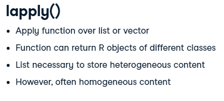

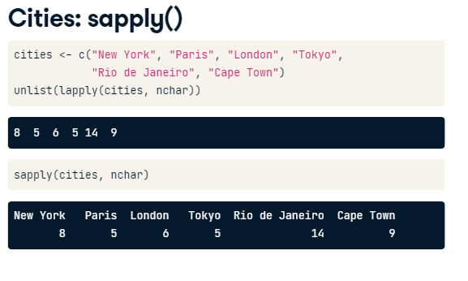

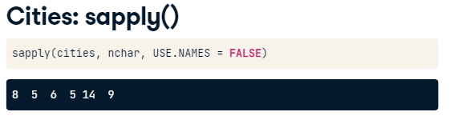

**How to use sapply**

You can use [sapply()](http://www.rdocumentation.org/packages/base/functions/lapply) similar to how you used [lapply()](http://www.rdocumentation.org/packages/base/functions/lapply). The first argument of [sapply()](http://www.rdocumentation.org/packages/base/functions/lapply) is the list or vector `X` over which you want to apply a function, `FUN`. Potential additional arguments to this function are specified afterwards (`...`):

```
sapply(X, FUN, ...)
```

In the next couple of exercises, you’ll be working with the variable `temp`, that contains temperature measurements for 7 days. `temp` is a list of length 7, where each element is a vector of length 5, representing 5 measurements on a given day. This variable has already been defined in the workspace: type `str(temp)` to see its structure.

```r
# temp has already been defined in the workspace
temp <- list(c(3,7,9,6,-1), c(6,9,12,13,5), c(4,8,3,-1,-3), c(1,4,7,2,-2), c(5,7,9,4,2), c(-3,5,8,9,4), c(3,6,9,4,1))
temp
```

```
## [[1]]
## [1]  3  7  9  6 -1
##
## [[2]]
## [1]  6  9 12 13  5
##
## [[3]]
## [1]  4  8  3 -1 -3
##
## [[4]]
## [1]  1  4  7  2 -2
##
## [[5]]
## [1] 5 7 9 4 2
##
## [[6]]
## [1] -3  5  8  9  4
##
## [[7]]
## [1] 3 6 9 4 1
```

```r
# Use lapply() to find each day's minimum temperature
lapply(temp, min)
```

```
## [[1]]
## [1] -1
##
## [[2]]
## [1] 5
##
## [[3]]
## [1] -3
##
## [[4]]
## [1] -2
##
## [[5]]
## [1] 2
##
## [[6]]
## [1] -3
##
## [[7]]
## [1] 1
```

```r
# Use sapply() to find each day's minimum temperature
sapply(temp, min)
```

```
## [1] -1  5 -3 -2  2 -3  1
```

```r
# Use lapply() to find each day's maximum temperature
lapply(temp, max)
```

```
## [[1]]
## [1] 9
##
## [[2]]
## [1] 13
##
## [[3]]
## [1] 8
##
## [[4]]
## [1] 7
##
## [[5]]
## [1] 9
##
## [[6]]
## [1] 9
##
## [[7]]
## [1] 9
```

```r
# Use sapply() to find each day's maximum temperature
sapply(temp, max)
```

```
## [1]  9 13  8  7  9  9  9
```

Nice! Can you tell the difference between the output of `lapply()` and `sapply()`? The former returns a list, while the latter returns a vector that is a simplified version of this list. Notice that this time, unlike in the cities example of the instructional video, the vector is not named.

**sapply with your own function**

Like [lapply()](http://www.rdocumentation.org/packages/base/functions/lapply), [sapply()](http://www.rdocumentation.org/packages/base/functions/lapply) allows you to use self-defined functions and apply them over a vector or a list:

```
sapply(X, FUN, ...)
```

Here, `FUN` can be one of R’s built-in functions, but it can also be a function you wrote. This self-written function can be defined before hand, or can be inserted directly as an anonymous function.

```r
# temp is already defined in the workspace

# Finish function definition of extremes_avg
extremes_avg <- function(x) {
  ( min(x) + max(x) ) / 2
}

# Apply extremes_avg() over temp using sapply()
sapply(temp, extremes_avg)
```

```
## [1] 4.0 9.0 2.5 2.5 5.5 3.0 5.0
```

```r
# Apply extremes_avg() over temp using lapply()
lapply(temp, extremes_avg)
```

```
## [[1]]
## [1] 4
##
## [[2]]
## [1] 9
##
## [[3]]
## [1] 2.5
##
## [[4]]
## [1] 2.5
##
## [[5]]
## [1] 5.5
##
## [[6]]
## [1] 3
##
## [[7]]
## [1] 5
```

Great job! Of course, you could have solved this exercise using an anonymous function, but this would require you to use the code inside the definition of `extremes_avg()` twice. Duplicating code should be avoided as much as possible!

**sapply with function returning vector** In the previous exercises, you’ve seen how [sapply()](http://www.rdocumentation.org/packages/base/functions/lapply) simplifies the list that [lapply()](http://www.rdocumentation.org/packages/base/functions/lapply) would return by turning it into a vector. But what if the function you’re applying over a list or a vector returns a vector of length greater than 1? If you don’t remember from the video, don’t waste more time in the valley of ignorance and head over to the instructions!

```r
# temp is already available in the workspace

# Create a function that returns min and max of a vector: extremes
extremes <- function(x) {
  c(min = min(x), max = max(x))
}

# Apply extremes() over temp with sapply()
sapply(temp, extremes)
```

```
##     [,1] [,2] [,3] [,4] [,5] [,6] [,7]
## min   -1    5   -3   -2    2   -3    1
## max    9   13    8    7    9    9    9
```

```r
# Apply extremes() over temp with lapply()
lapply(temp, extremes)
```

```
## [[1]]
## min max
##  -1   9
##
## [[2]]
## min max
##   5  13
##
## [[3]]
## min max
##  -3   8
##
## [[4]]
## min max
##  -2   7
##
## [[5]]
## min max
##   2   9
##
## [[6]]
## min max
##  -3   9
##
## [[7]]
## min max
##   1   9
```

Wonderful! Have a final look at the console and see how `sapply()` did a great job at simplifying the rather uninformative ‘list of vectors’ that `lapply()` returns. It actually returned a nicely formatted matrix!

**sapply can’t simplify, now what?**

It seems like we’ve hit the jackpot with [sapply()](http://www.rdocumentation.org/packages/base/functions/lapply). On all of the examples so far, [sapply()](http://www.rdocumentation.org/packages/base/functions/lapply) was able to nicely simplify the rather bulky output of [lapply()](http://www.rdocumentation.org/packages/base/functions/lapply). But, as with life, there are things you can’t simplify. How does [sapply()](http://www.rdocumentation.org/packages/base/functions/lapply) react?

We already created a function, `below_zero()`, that takes a vector of numerical values and returns a vector that only contains the values that are strictly below zero.

```r
# temp is already prepared for you in the workspace

# Definition of below_zero()
below_zero <- function(x) {
  return(x[x < 0])
}

# Apply below_zero over temp using sapply(): freezing_s
freezing_s <- sapply(temp, below_zero)
freezing_s
```

```
## [[1]]
## [1] -1
##
## [[2]]
## numeric(0)
##
## [[3]]
## [1] -1 -3
##
## [[4]]
## [1] -2
##
## [[5]]
## numeric(0)
##
## [[6]]
## [1] -3
##
## [[7]]
## numeric(0)
```

```r
# Apply below_zero over temp using lapply(): freezing_l
freezing_l <- lapply(temp, below_zero)
freezing_l
```

```
## [[1]]
## [1] -1
##
## [[2]]
## numeric(0)
##
## [[3]]
## [1] -1 -3
##
## [[4]]
## [1] -2
##
## [[5]]
## numeric(0)
##
## [[6]]
## [1] -3
##
## [[7]]
## numeric(0)
```

```r
# Are freezing_s and freezing_l identical?
identical(freezing_s, freezing_l)
```

```
## [1] TRUE
```

Nice one! Given that the length of the output of `below_zero()` changes for different input vectors, `sapply()` is not able to nicely convert the output of `lapply()` to a nicely formatted matrix. Instead, the output values of `sapply()` and `lapply()` are exactly the same, as shown by the `TRUE` output of `identical()`.

**sapply with functions that return NULL**

A function `print_info()`, that takes a vector and prints the average of this vector, has already been created for you. It uses the [cat()](http://www.rdocumentation.org/packages/base/functions/cat) function.

```r
# temp is already available in the workspace

# Definition of print_info()
print_info <- function(x) {
  cat("The average temperature is", mean(x), "\n")
}

# Apply print_info() over temp using sapply()
sapply(temp, print_info)
```

```
## The average temperature is 4.8
## The average temperature is 9
## The average temperature is 2.2
## The average temperature is 2.4
## The average temperature is 5.4
## The average temperature is 4.6
## The average temperature is 4.6
```

```r
# Apply print_info() over temp using lapply()
lapply(temp, print_info)
```

```
## The average temperature is 4.8
## The average temperature is 9
## The average temperature is 2.2
## The average temperature is 2.4
## The average temperature is 5.4
## The average temperature is 4.6
## The average temperature is 4.6
```

**vapply**

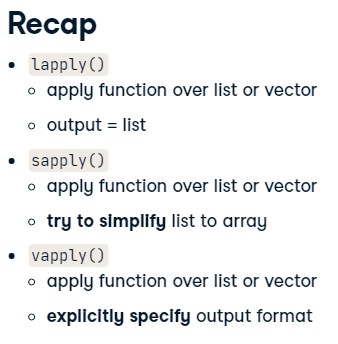

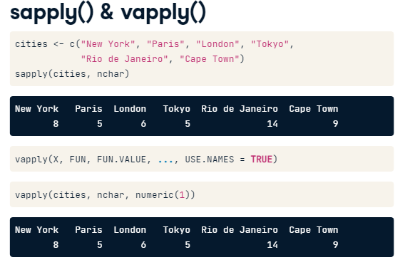

**Use vapply**

Before you get your hands dirty with the third and last apply function that you’ll learn about in this intermediate R course, let’s take a look at its syntax. The function is called [vapply()](http://www.rdocumentation.org/packages/base/functions/lapply), and it has the following syntax:

```
vapply(X, FUN, FUN.VALUE, ..., USE.NAMES = TRUE)
```

Over the elements inside `X`, the function `FUN` is applied. The `FUN.VALUE` argument expects a template for the return argument of this function `FUN`. `USE.NAMES` is `TRUE` by default; in this case [vapply()](http://www.rdocumentation.org/packages/base/functions/lapply) tries to generate a named array, if possible.

For the next set of exercises, you’ll be working on the `temp` list again, that contains 7 numerical vectors of length 5. We also coded a function `basics()` that takes a vector, and returns a named vector of length 3, containing the minimum, mean and maximum value of the vector respectively.

```r
# temp is already available in the workspace

# Definition of basics()
basics <- function(x) {
  c(min = min(x), mean = mean(x), max = max(x))
}

# Apply basics() over temp using vapply()
vapply(temp, basics, numeric(3))
```

```
##      [,1] [,2] [,3] [,4] [,5] [,6] [,7]
## min  -1.0    5 -3.0 -2.0  2.0 -3.0  1.0
## mean  4.8    9  2.2  2.4  5.4  4.6  4.6
## max   9.0   13  8.0  7.0  9.0  9.0  9.0
```

Perfect! Notice how, just as with `sapply()`, `vapply()` neatly transfers the names that you specify in the `basics()` function to the row names of the matrix that it returns.

**Use vapply (2)**

So far you’ve seen that [vapply()](http://www.rdocumentation.org/packages/base/functions/lapply) mimics the behavior of [sapply()](http://www.rdocumentation.org/packages/base/functions/lapply) if everything goes according to plan. But what if it doesn’t?

In the video, Filip showed you that there are cases where the structure of the output of the function you want to apply, `FUN`, does not correspond to the template you specify in `FUN.VALUE`. In that case, [vapply()](http://www.rdocumentation.org/packages/base/functions/lapply) will throw an error that informs you about the misalignment between expected and actual output.

```r
# temp is already available in the workspace

# Definition of the basics() function
basics <- function(x) {
  c(min = min(x), mean = mean(x), median = median(x), max = max(x))
}

# Fix the error:
vapply(temp, basics, numeric(4))
```

```
##        [,1] [,2] [,3] [,4] [,5] [,6] [,7]
## min    -1.0    5 -3.0 -2.0  2.0 -3.0  1.0
## mean    4.8    9  2.2  2.4  5.4  4.6  4.6
## median  6.0    9  3.0  2.0  5.0  5.0  4.0
## max     9.0   13  8.0  7.0  9.0  9.0  9.0
```

**From sapply to vapply**

As highlighted before, [vapply()](http://www.rdocumentation.org/packages/base/functions/lapply) can be considered a more robust version of [sapply()](http://www.rdocumentation.org/packages/base/functions/lapply), because you explicitly restrict the output of the function you want to apply. Converting your [sapply()](http://www.rdocumentation.org/packages/base/functions/lapply) expressions in your own R scripts to [vapply()](http://www.rdocumentation.org/packages/base/functions/lapply) expressions is therefore a good practice (and also a breeze!).

```r
# temp is already defined in the workspace

# Convert to vapply() expression
vapply(temp, max, numeric(1))
```

```
## [1]  9 13  8  7  9  9  9
```

```r
# Convert to vapply() expression
vapply(temp, function(x, y) { mean(x) > y }, logical(1), y = 5)
```

```
## [1] FALSE  TRUE FALSE FALSE  TRUE FALSE FALSE
```

Great! You’ve got no more excuses to use `sapply()` in the future!

**Useful Functions**

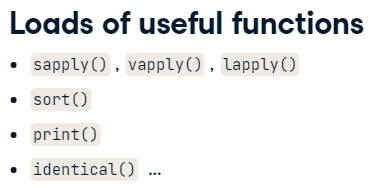

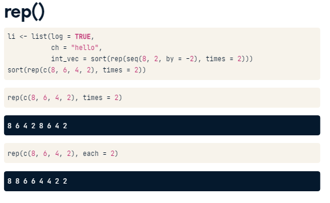

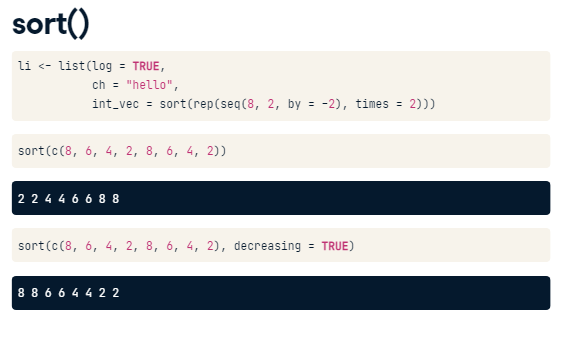

**Mathematical utilities**

Have another look at some useful math functions that R features:

- [abs()](http://www.rdocumentation.org/packages/base/functions/MathFun): Calculate the absolute value.
- [sum()](http://www.rdocumentation.org/packages/base/functions/sum): Calculate the sum of all the values in a data structure.
- [mean()](http://www.rdocumentation.org/packages/base/functions/mean): Calculate the arithmetic mean.
- [round()](http://www.rdocumentation.org/packages/base/functions/round): Round the values to 0 decimal places by default. Try out `?round` in the console for variations of `round()` and ways to change the number of digits to round to.

As a data scientist in training, you’ve estimated a regression model on the sales data for the past six months. After evaluating your model, you see that the training error of your model is quite regular, showing both positive and negative values. The error values are already defined in the workspace (`errors`).

```r
# The errors vector has already been defined for you
errors <- c(1.9, -2.6, 4.0, -9.5, -3.4, 7.3)

# Sum of absolute rounded values of errors
sum(abs(round(errors)))
```

```
## [1] 29
```

**Find the error**

We went ahead and included some code on the right, but there’s still an error. Can you trace it and fix it?

In times of despair, help with functions such as [sum()](http://www.rdocumentation.org/packages/base/functions/sum) and [rev()](http://www.rdocumentation.org/packages/base/functions/rev) are a single command away; simply use`?sum` and `?rev` in the console.

```r
# Don't edit these two lines
vec1 <- c(1.5, 2.5, 8.4, 3.7, 6.3)
vec2 <- rev(vec1)

# Fix the error
#mean(abs(vec1), abs(vec2))
mean(c(abs(vec1), abs(vec2)))
```

```
## [1] 4.48
```

Nice work! If you check out the documentation of `mean()`, you’ll see that only the first argument, `x`, should be a vector. If you also specify a second argument, R will match the arguments by position and expect a specification of the `trim` argument. Therefore, merging the two vectors is a must!

**Data Utilities**

R features a bunch of functions to juggle around with data structures:

- [seq()](http://www.rdocumentation.org/packages/base/functions/seq): Generate sequences, by specifying the `from`, `to`, and `by` arguments.
- [rep()](http://www.rdocumentation.org/packages/base/functions/rep): Replicate elements of vectors and lists.
- [sort()](http://www.rdocumentation.org/packages/base/functions/sort): Sort a vector in ascending order. Works on numerics, but also on character strings and logicals.
- [rev()](http://www.rdocumentation.org/packages/base/functions/rev): Reverse the elements in a data structures for which reversal is defined.
- [str()](http://www.rdocumentation.org/packages/utils/functions/str): Display the structure of any R object.
- [append()](http://www.rdocumentation.org/packages/base/functions/append): Merge vectors or lists.
- `is.*()`: Check for the class of an R object.
- `as.*()`: Convert an R object from one class to another.
- [unlist()](http://www.rdocumentation.org/packages/base/functions/unlist): Flatten (possibly embedded) lists to produce a vector.

Remember the social media profile views data? Your LinkedIn and Facebook view counts for the last seven days are already defined as lists on the right.

```r
# The linkedin and facebook lists have already been created for you
linkedin <- list(16, 9, 13, 5, 2, 17, 14)
facebook <- list(17, 7, 5, 16, 8, 13, 14)

# Convert linkedin and facebook to a vector: li_vec and fb_vec
li_vec <- unlist(linkedin)
fb_vec <- unlist(facebook)

# Append fb_vec to li_vec: social_vec
social_vec <- append(li_vec, fb_vec)

# Sort social_vec
sort(social_vec, decreasing = TRUE)
```

```
##  [1] 17 17 16 16 14 14 13 13  9  8  7  5  5  2
```

Wonderful! These instructions required you to solve this challenge in a step-by-step approach. If you’re comfortable with the functions, you can combine some of these steps into powerful one-liners.

**Find the error (2)**

Just as before, let’s switch roles. It’s up to you to see what unforgivable mistakes we’ve made. Go fix them!

```r
# Fix me
#seq(rep(1, 7, by = 2), times = 7)
rep(seq(1, 7, by = 2), times = 7)
```

```
##  [1] 1 3 5 7 1 3 5 7 1 3 5 7 1 3 5 7 1 3 5 7 1 3 5 7 1 3 5 7
```

Wonderful! Debugging code is also a big part of the daily routine of a data scientist, and you seem to be great at it!

**Beat Gauss using R**

There is a popular story about young Gauss. As a pupil, he had a lazy teacher who wanted to keep the classroom busy by having them add up the numbers 1 to 100. Gauss came up with an answer almost instantaneously, 5050. On the spot, he had developed a formula for calculating the sum of an arithmetic series. There are more general formulas for calculating the sum of an arithmetic series with different starting values and increments. Instead of deriving such a formula, why not use R to calculate the sum of a sequence?

```r
# Create first sequence: seq1
seq1 <- seq(1, 500, by = 3)

# Create second sequence: seq2
seq2 <- seq(1200, 900, by = -7)

# Calculate total sum of the sequences
sum(seq1) + sum(seq2)
```

```
## [1] 87029
```

**Regular Expressions**

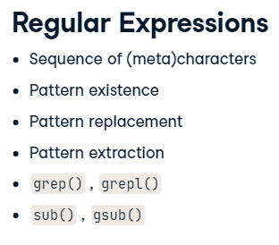

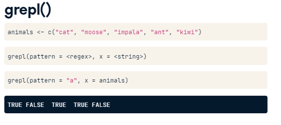

- pattern: `^a` - starts with
- pattern: `a$` - ends with
- `?regex`
- `grep()` returns indices that match regex pattern
  - i.e. `which(grepl())`

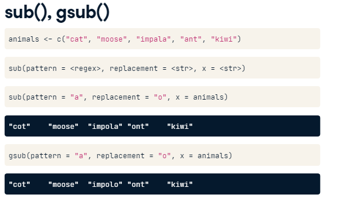

- `sub()` replaces first instance
- `gsub()` replaces all instances
- logical or `|` can be used to combine multiple characters in `regex`

**grepl & grep**

In their most basic form, regular expressions can be used to see whether a pattern exists inside a character string or a vector of character strings. For this purpose, you can use:

- [grepl()](http://www.rdocumentation.org/packages/base/functions/grep), which returns TRUE when a pattern is found in the corresponding character string.
- [grep()](http://www.rdocumentation.org/packages/base/functions/grep), which returns a vector of indices of the character strings that contains the pattern.

Both functions need a `pattern` and an `x` argument, where `pattern` is the regular expression you want to match for, and the `x` argument is the character vector from which matches should be sought.

In this and the following exercises, you’ll be querying and manipulating a character vector of email addresses! The vector `emails` has already been defined so you can begin with the instructions straight away!

```r
# The emails vector has already been defined for you
emails <- c("john.doe@ivyleague.edu", "education@world.gov", "dalai.lama@peace.org",
            "invalid.edu", "quant@bigdatacollege.edu", "cookie.monster@sesame.tv")

# Use grepl() to match for "edu"
grepl("edu", emails)
```

```
## [1]  TRUE  TRUE FALSE  TRUE  TRUE FALSE
```

```r
# Use grep() to match for "edu", save result to hits
hits <- grep("edu", emails)

# Subset emails using hits
emails[hits]
```

```
## [1] "john.doe@ivyleague.edu"   "education@world.gov"
## [3] "invalid.edu"              "quant@bigdatacollege.edu"
```

Bellissimo! You can probably guess what we’re trying to achieve here: select all the emails that end with “.edu”. However, the strings `education@world.gov` and `invalid.edu` were also matched. Let’s see in the next exercise what you can do to improve our pattern and remove these false positives.

**grepl & grep (2)**

You can use the caret, `^`, and the dollar sign, `$` to match the content located in the start and end of a string, respectively. This could take us one step closer to a correct pattern for matching only the “.edu” email addresses from our list of emails. But there’s more that can be added to make the pattern more robust:

- `@`, because a valid email must contain an at-sign.
- `.*`, which matches any character (.) zero or more times (*). Both the dot and the asterisk are metacharacters. You can use them to match any character between the at-sign and the “.edu” portion of an email address.
- `\\.edu$`, to match the “.edu” part of the email at the end of the string. The \ part *escapes* the dot: it tells R that you want to use the `.` as an actual character.

```r
# The emails vector has already been defined for you
emails <- c("john.doe@ivyleague.edu", "education@world.gov", "dalai.lama@peace.org",
            "invalid.edu", "quant@bigdatacollege.edu", "cookie.monster@sesame.tv")

# Use grepl() to match for .edu addresses more robustly
grepl("@.*\\.edu$", emails)
```

```
## [1]  TRUE FALSE FALSE FALSE  TRUE FALSE
```

```r
# Use grep() to match for .edu addresses more robustly, save result to hits
hits <- grep("@.*\\.edu$", emails)

# Subset emails using hits
emails[hits]
```

```
## [1] "john.doe@ivyleague.edu"   "quant@bigdatacollege.edu"
```

Great! A careful construction of our regular expression leads to more meaningful matches. However, even our robust email selector will often match some incorrect email addresses (for instance `kiara@@fakemail.edu`). Let’s not worry about this too much and continue with `sub()` and `gsub()` to actually edit the email addresses!

**sub & gsub**

While [grep()](http://www.rdocumentation.org/packages/base/functions/grep) and [grepl()](http://www.rdocumentation.org/packages/base/functions/grep) were used to simply check whether a regular expression could be matched with a character vector, [sub()](http://www.rdocumentation.org/packages/base/functions/grep) and [gsub()](http://www.rdocumentation.org/packages/base/functions/grep) take it one step further: you can specify a `replacement` argument. If inside the character vector `x`, the regular expression pattern is found, the matching element(s) will be replaced with `replacement`.[sub()](http://www.rdocumentation.org/packages/base/functions/grep) only replaces the first match, whereas [gsub()](http://www.rdocumentation.org/packages/base/functions/grep) replaces all matches.

Suppose that `emails` vector you’ve been working with is an excerpt of DataCamp’s email database. Why not offer the owners of the .edu email addresses a new email address on the datacamp.edu domain? This could be quite a powerful marketing stunt: Online education is taking over traditional learning institutions! Convert your email and be a part of the new generation!

```r
# The emails vector has already been defined for you
emails <- c("john.doe@ivyleague.edu", "education@world.gov", "global@peace.org",
            "invalid.edu", "quant@bigdatacollege.edu", "cookie.monster@sesame.tv")

# Use sub() to convert the email domains to datacamp.edu
sub("@.*\\.edu$", "@datacamp.edu", emails)
```

```
## [1] "john.doe@datacamp.edu"    "education@world.gov"
## [3] "global@peace.org"         "invalid.edu"
## [5] "quant@datacamp.edu"       "cookie.monster@sesame.tv"
```

Awesome! Notice how only the valid .edu addresses are changed while the other emails remain unchanged. To get a taste of other things you can accomplish with regex, head over to the next exercise.

More regex:

- `.*`: A usual suspect! It can be read as “any character that is matched zero or more times”.
- `\\s`: Match a space. The “s” is normally a character, escaping it (`\\`) makes it a metacharacter.
- `[0-9]+`: Match the numbers 0 to 9, at least once (+).
- `([0-9]+)`: The parentheses are used to make parts of the matching string available to define the replacement. The `\\1` in the replacement argument of [sub()](http://www.rdocumentation.org/packages/base/functions/grep) gets set to the string that is captured by the regular expression `[0-9]+`.

**Times & Dates**

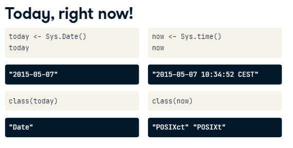

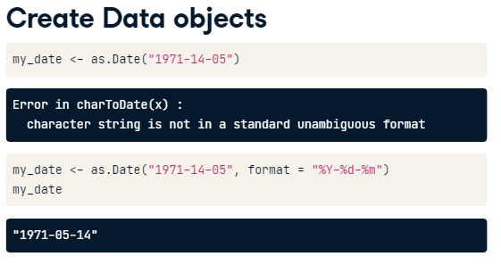

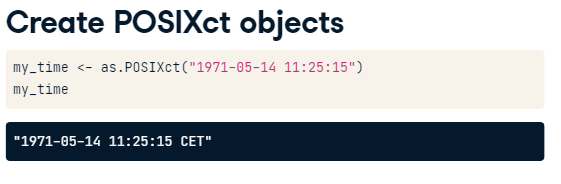

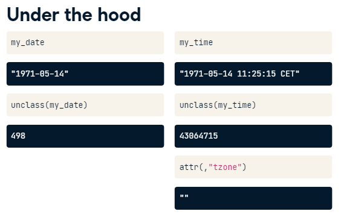

**Dedicated R Packages**

- `lubridate`
- `zoo`
- `xts`

**Right here, right now**

In R, dates are represented by `Date` objects, while times are represented by `POSIXct` objects. Under the hood, however, these dates and times are simple numerical values. `Date` objects store the number of days since the 1st of January in 1970. `POSIXct` objects on the other hand, store the number of seconds since the 1st of January in 1970.

The 1st of January in 1970 is the common origin for representing times and dates in a wide range of programming languages. There is no particular reason for this; it is a simple convention. Of course, it’s also possible to create dates and times before 1970; the corresponding numerical values are simply negative in this case.

```r
# Get the current date: today
today <- Sys.Date()

# See what today looks like under the hood
unclass(today)
```

```
## [1] 18600
```

```r
# Get the current time: now
now <- Sys.time()

# See what now looks like under the hood
unclass(now)
```

```
## [1] 1607063643
```

Great! Using R to get the current date and time is nice, but you should also know how to create dates and times from character strings. Find out how in the next exercises!

**Create and format dates**

To create a `Date` object from a simple character string in R, you can use the [as.Date()](http://www.rdocumentation.org/packages/base/functions/as.Date) function. The character string has to obey a format that can be defined using a set of symbols (the examples correspond to 13 January, 1982):

- `%Y`: 4-digit year (1982)
- `%y`: 2-digit year (82)
- `%m`: 2-digit month (01)
- `%d`: 2-digit day of the month (13)
- `%A`: weekday (Wednesday)
- `%a`: abbreviated weekday (Wed)
- `%B`: month (January)
- `%b`: abbreviated month (Jan)

The following R commands will all create the same `Date` object for the 13th day in January of 1982:

```
as.Date("1982-01-13")
as.Date("Jan-13-82", format = "%b-%d-%y")
as.Date("13 January, 1982", format = "%d %B, %Y")
```

Notice that the first line here did not need a format argument, because by default R matches your character string to the formats `"%Y-%m-%d"` or `"%Y/%m/%d"`.

In addition to creating dates, you can also convert dates to character strings that use a different date notation. For this, you use the [format()](http://www.rdocumentation.org/packages/base/functions/format) function. Try the following lines of code:

```
today <- Sys.Date()
format(Sys.Date(), format = "%d %B, %Y")
format(Sys.Date(), format = "Today is a %A!")
```

```r
# Definition of character strings representing dates
str1 <- "May 23, '96"
str2 <- "2012-03-15"
str3 <- "30/January/2006"

# Convert the strings to dates: date1, date2, date3
date1 <- as.Date(str1, format = "%b %d, '%y")
date2 <- as.Date(str2)
date3 <- as.Date(str3, format = "%d/%B/%Y")

# Convert dates to formatted strings
format(date1, "%A")
```

```
## [1] "Thursday"
```

```r
format(date2, "%d")
```

```
## [1] "15"
```

```r
format(date3, "%b %Y")
```

```
## [1] "Jan 2006"
```

You’re a date magician! You can use `POSIXct` objects, i.e. Time objects in R, in a similar fashion. Give it a try in the next exercise.

**Create and format times**

Similar to working with dates, you can use [as.POSIXct()](http://www.rdocumentation.org/packages/base/functions/as.POSIXlt) to convert from a character string to a `POSIXct` object, and [format()](http://www.rdocumentation.org/packages/base/functions/format) to convert from a `POSIXct` object to a character string. Again, you have a wide variety of symbols:

- `%H`: hours as a decimal number (00-23)
- `%I`: hours as a decimal number (01-12)
- `%M`: minutes as a decimal number
- `%S`: seconds as a decimal number
- `%T`: shorthand notation for the typical format `%H:%M:%S`
- `%p`: AM/PM indicator

For a full list of conversion symbols, consult the `strptime` documentation in the console:

```
?strptime
```

Again, [as.POSIXct()](http://www.rdocumentation.org/packages/base/functions/as.POSIXlt) uses a default format to match character strings. In this case, it’s`%Y-%m-%d %H:%M:%S`. In this exercise, abstraction is made of different time zones.

```r
# Definition of character strings representing times
str1 <- "May 23, '96 hours:23 minutes:01 seconds:45"
str2 <- "2012-3-12 14:23:08"

# Convert the strings to POSIXct objects: time1, time2
time1 <- as.POSIXct(str1, format = "%B %d, '%y hours:%H minutes:%M seconds:%S")
time2 <- as.POSIXct(str2)

# Convert times to formatted strings
format(time1, "%M")
```

```
## [1] "01"
```

```r
format(time2, "%I:%M %p")
```

```
## [1] "02:23 PM"
```

**Calculations with Dates**

Both `Date` and `POSIXct` R objects are represented by simple numerical values under the hood. This makes calculation with time and date objects very straightforward: R performs the calculations using the underlying numerical values, and then converts the result back to human-readable time information again.

You can increment and decrement `Date` objects, or do actual calculations with them (try it out in the console!):

```
today <- Sys.Date()
today + 1
today - 1

as.Date("2015-03-12") - as.Date("2015-02-27")
```

To control your eating habits, you decided to write down the dates of the last five days that you ate pizza. In the workspace, these dates are defined as five `Date` objects, `day1` to `day5`. The code also contains a vector `pizza` with these 5 `Date` objects.

```r
# day1, day2, day3, day4 and day5 are already available in the workspace
day1 <- as.Date("2020-11-16")
day2 <- as.Date("2020-11-18")
day3 <- as.Date("2020-11-23")
day4 <- as.Date("2020-11-29")
day5 <- as.Date("2020-12-04")

# Difference between last and first pizza day
day5 - day1
```

```
## Time difference of 18 days
```

```r
# Create vector pizza
pizza <- c(day1, day2, day3, day4, day5)

# Create differences between consecutive pizza days: day_diff
day_diff <- diff(pizza)

# Average period between two consecutive pizza days
mean(day_diff)
```

```
## Time difference of 4.5 days
```

**Calculations with Times**

Calculations using `POSIXct` objects are completely analogous to those using `Date` objects. Try to experiment with this code to increase or decrease `POSIXct` objects:

```
now <- Sys.time()
now + 3600          # add an hour
now - 3600 * 24     # subtract a day
```

Adding or subtracting time objects is also straightforward:

```
birth <- as.POSIXct("1879-03-14 14:37:23")
death <- as.POSIXct("1955-04-18 03:47:12")
einstein <- death - birth
einstein
```

You’re developing a website that requires users to log in and out. You want to know what is the total and average amount of time a particular user spends on your website. This user has logged in 5 times and logged out 5 times as well. These times are gathered in the vectors `login` and `logout`, which are already defined in the workspace.

```r
# login and logout are already defined in the workspace
login <- as.POSIXct(c("2020-11-20 10:18:04 UTC","2020-11-25 09:14:18 UTC","2020-11-25 12:21:51 UTC","2020-11-25 12:37:24 UTC","2020-11-27 21:37:55 UTC"))

logout <- as.POSIXct(c("2020-11-20 10:56:29 UTC","2020-11-25 09:14:52 UTC","2020-11-25 12:35:48 UTC","2020-11-25 13:17:22 UTC","2020-11-27 22:08:47 UTC"))

# Calculate the difference between login and logout: time_online
time_online <- logout - login

# Inspect the variable time_online
time_online
```

```
## Time differences in secs
## [1] 2305   34  837 2398 1852
```

```r
# Calculate the total time online
sum(time_online)
```

```
## Time difference of 7426 secs
```

```r
# Calculate the average time online
mean(time_online)
```

```
## Time difference of 1485.2 secs
```

**Time is of the essence**

The dates when a season begins and ends can vary depending on who you ask. People in Australia will tell you that spring starts on September 1st. The Irish people in the Northern hemisphere will swear that spring starts on February 1st, with the celebration of St. Brigid’s Day. Then there’s also the difference between astronomical and meteorological seasons: while astronomers are used to equinoxes and solstices, meteorologists divide the year into 4 fixed seasons that are each three months long. (source: www.timeanddate.com)

A vector `astro`, which contains character strings representing the dates on which the 4 astronomical seasons start, has been defined on your workspace. Similarly, a vector `meteo` has already been created for you, with the meteorological beginnings of a season.

```r
astro <- c(spring = "20-Mar-2015" , summer = "25-Jun-2015", fall = "23-Sep-2015", winter = "22-Dec-2015")
meteo <- c(spring = "March 1, 15", summer = "June 1, 15", fall = "September 1, 15", winter = "December 1, 15")

# Convert astro to vector of Date objects: astro_dates
astro_dates <- as.Date(astro, format = "%d-%b-%Y")

# Convert meteo to vector of Date objects: meteo_dates
meteo_dates <- as.Date(meteo, format = "%B %d, %y")

# Calculate the maximum absolute difference between astro_dates and meteo_dates
max(abs(meteo_dates - astro_dates))
```

```
## Time difference of 24 days
```